[output not shown]

# Regression Models Course Project Report

## Martin Hediger

### Executive Summary

This short report analyses if 1) automatic or manual transmission results in larger miles-per-gallon (mpg) and 2) quantifies the effect of manual or automatic transmission on mpg in the cars from the `mtcars` dataset.  
Automatic transmission vehicles appear to be less efficient than manual transmission vehicles (Fig. “box-scat” A). A linear relationship between miles-per-gallon range and car weight for both automatic and manual transmission vehicles is found (Fig. “box-scat” B).

### Exploratory Analysis

As an initial test, dependence of `mpg` on `wt` is analysed.  
[`box-scat`](https://github.com/mzhKU/regmods_course_project/blob/master/box-scat.R) A: Boxplot, B: Scatterplot of `mpg` against `wt`.

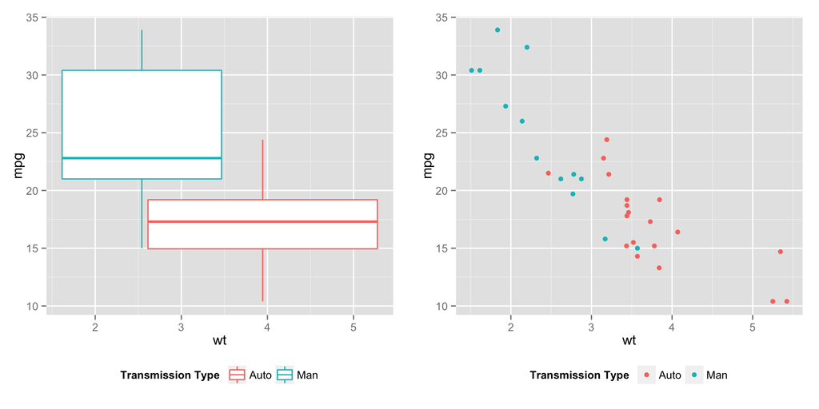

[Source code for the panel plot](https://github.com/mzhKU/regmods_course_project/blob/master/multiplot.R).

According to the boxplot, automatic cars have lower MPG (and possibly lower variance in the data). Importantly, the relationships appear linear and no outliers which could affect correlation values are identified. The only aspect which is slightly problematic is the limited dataset size (n=32).  
It is noted that apparently most cars with automatic transmission also are heavier which possibly confounds the observation, this would be subject to further research.

### Results

**Question 1: Which transmission type has higher MPG?**  
Based on the exploratory analysis above, it is found that on average the difference between MPG(auto) and MPG(man) is around 7.2449 miles-per-gallon (=`mean(mtcars[mtcars$am==1, "mpg"]) - mean(mtcars[mtcars$am==0, "mpg"])`).

```r
fit_full <- lm(mpg ~   + factor(am), data=mtcars)
summary(fit_full)$coefficients
```

```
##             Estimate Std. Error t value  Pr(>|t|)
## (Intercept)   17.147      1.125  15.247 1.134e-15
## factor(am)1    7.245      1.764   4.106 2.850e-04
```